# Zambia MAIZE Forescasts

Dr. -Ing. MISK Benson Kenduiywo

```r
library(knitr)
opts_chunk$set(tidy.opts = list(width.cutoff = 60))
opts_knit$set(global.par = TRUE)
```

## Reference data

Load Zambia’s ministry of agriculture maize forecasts data as reference.

Load data

```
## [1] "Province"      "District"      "planted_ha"    "harvested_ha"
## [5] "production_MT" "yield_MT_ha"   "Year"
```

Convert District and province names to upper case.

```
##  [1] "CENTRAL"       "COPPERBELT"    "EASTERN"       "LUAPULA"
##  [5] "LUSAKA"        "MUCHINGA"      "NORTH-WESTERN" "NORTHERN"
##  [9] "SOUTHERN"      "WESTERN"
```

Districts

| x |
| --- |
| CHADIZA |
| CHAMA |
| CHAVUMA |
| CHIBOMBO |
| CHIENGE |
| CHILILABOMBWE |

Visualize the crop forecasting data from MoA per year.

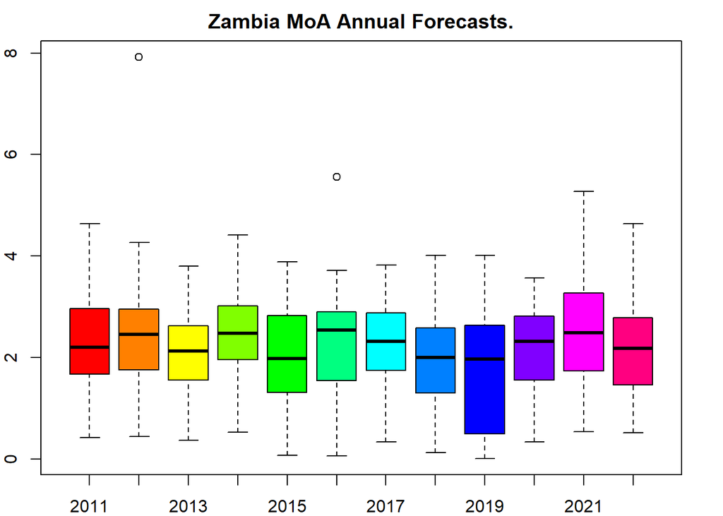

```r
boxplot(yield_MT_ha~Year, data=ref, col=rainbow(length(unique(ref$Year))), xlab="Year", ylab = "Yield (MT/ha)", main="Zambia MoA Annual Forecasts.")
```

Visualize the crop forecasting data from MoA per Province.

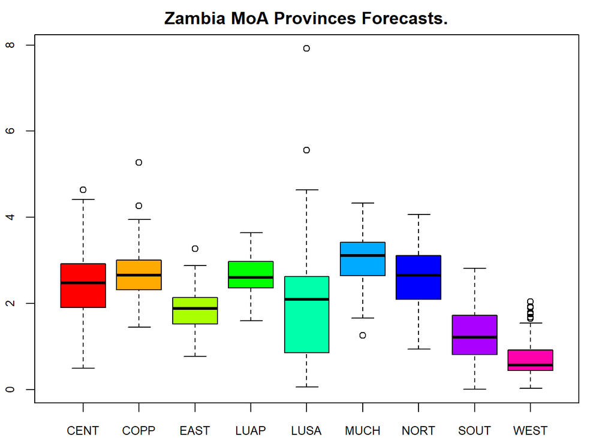

Aggregate MoA forecasts per district.

## RHEAS simulated yields

Load and aggregate RHEAS simulated Leaf Area Index (LAI), Water stress and Grain Weight Average Dry (GWAD) across different ensembles. Extract year from dates (we will use harvest year).

## Production forecast and RHEAS metrics aggregagation

Aggregate RHEAS production forecasts and metrics with respect to Districts maize growing calendar.

The maize growing season in Zambia starts from October to end of June. So we will aggregate the metrics and forecast with this condition using the function `RH_metrics`.

Convert RHEAS yields from kg/ha to MT/ha.

## Visualization

Add shapefile for visualization.

Check and format District names to be consistent in both the RHEAS and administrative boundaries.

```
## character(0)
```

```
## [1] "IKELENGE" "MAFINGA"
```

Merge RHEAS and Admin data.

Visualize RHEAS predicted yields spatially.

[interactive chart not shown]

## Planting/Harvest date detection

Lets Evaluate earliest Planting and harvest dates or months over the years according to the model’s detection.

| Plant_Early | Plant_Late | Harvest_Early | Harvest_Late | District |
| --- | --- | --- | --- | --- |
| 2021-11-05 | 2022-02-20 | 2022-03-06 | 2022-06-22 | CHADIZA |
| 2021-11-05 | 2022-02-20 | 2022-03-06 | 2022-06-22 | CHAMA |
| 2021-11-05 | 2022-02-20 | 2022-03-06 | 2022-06-22 | CHAVUMA |
| 2021-11-05 | 2022-02-20 | 2022-03-06 | 2022-06-22 | CHIBOMBO |
| 2021-11-05 | 2022-02-20 | 2022-03-06 | 2022-06-22 | CHIENGE |
| 2021-11-05 | 2022-02-20 | 2022-03-06 | 2022-06-22 | CHILUBI |

## Validation

Compare RHEAS with MoA forecasts.

First check consistency in Districts names.

```
## character(0)
```

Merge the MoA forecasts with RHEAS ones by year and District.

Plot RHEAS forecast versus MoA forecasts.

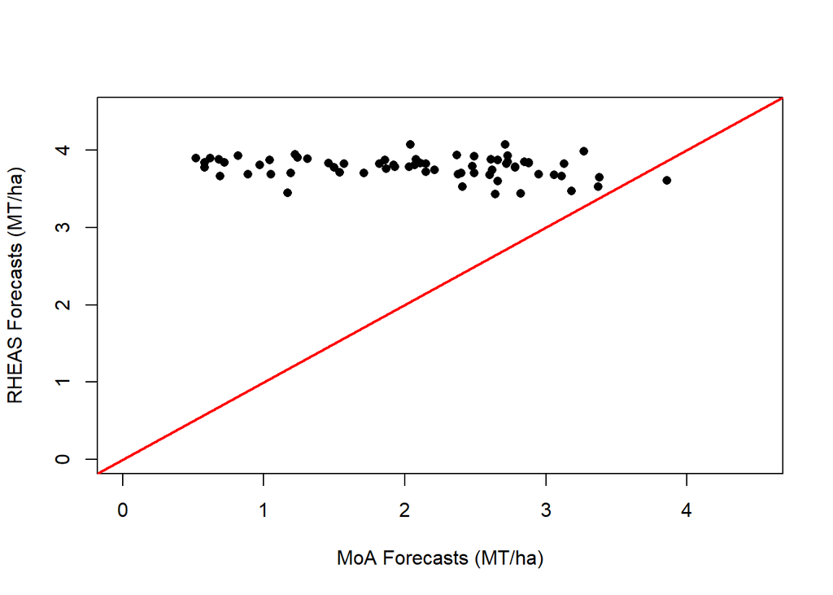

Plot the two datasets trends.

[figure not shown]

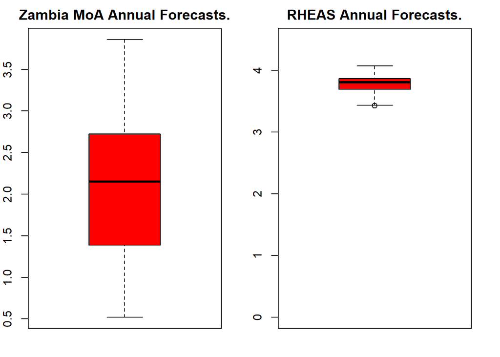

We can use the Root Mean Square Error (RMSE) and mean absolute percentage error (MAPE) to evaluate the models accuracy. RMSE is given as:

$$\text{RMSE} = \sqrt{\frac{1}{n} \sum_{i=1}^n y-\widehat{y}},$$
where $\widehat{y}$ and $y$ are predicted yields and observed yields respectively while *n* is the number of fitted points.

Compute RMSE.

```
## CHIRPS  1.911147
```

```
## TAMSAT  1.704165
```

What about Relative root mean square error (RRMSE):

$$\text{RRMSE} = \frac{\sqrt{\frac{1}{n} \sum_{i=1}^n
y-\widehat{y}}}{\frac{1}{n} \sum_{i=1}^n y},$$

Compute RRMSE.

```
## CHIRPS RRMSE  91.91504
```

```
## TAMSAT RRMSE  80.50242
```

According to Li et al. 2013, the performance of the model is excellent when RRMSE < 10%; good if 10% < RRMSE < 20%; fair if 20% < RRMSE < 30%; and poor if RRMSE ≥ 30%.